# open_questions

--- title: "Assignment 3: Sentiment Classification Reflection" format: html: toc: true toc-title: Contents toc-depth: 4 self-contained: true number-sections: false jupyter: python3 ---

## AI Use Disclosure (Required)

If you used any AI-enabled tools (e.g., ChatGPT, GitHub Copilot, Claude, or other LLM assistants) while working on this assignment, you must disclose that use here. The goal is transparency-not punishment.

In your disclosure, briefly include:

- **Tool(s) used:** (name + version if known)
- **How you used them:** (e.g., concept explanation, debugging, drafting code, rewriting text)
- **What you verified yourself:** (e.g., reran the notebook, checked outputs/plots, checked shapes, read documentation)
- **What you did *not* use AI for (if applicable):** (optional)

You are responsible for the correctness of your submission, even if AI suggested code or explanations.

#### AI Disclosure

- **Tool(s) used:** ChatGPT (GPT-5.2)
- **How I used it:** I used ChatGPT to look up answers for the open-ended reflection questions and to help write parts of the training scripts.
- **What I verified myself:** I wrote the main code structure myself, ran all six training scripts end-to-end, and checked all outputs, plots, and metrics to make sure everything was correct.
- **What I did not use AI for:** Model architecture design and hyperparameter selection.

## Open-Ended Reflection Questions

## 1. Training Dynamics

*Focus on MLP and LSTM implementations*

MLP Learning Curves

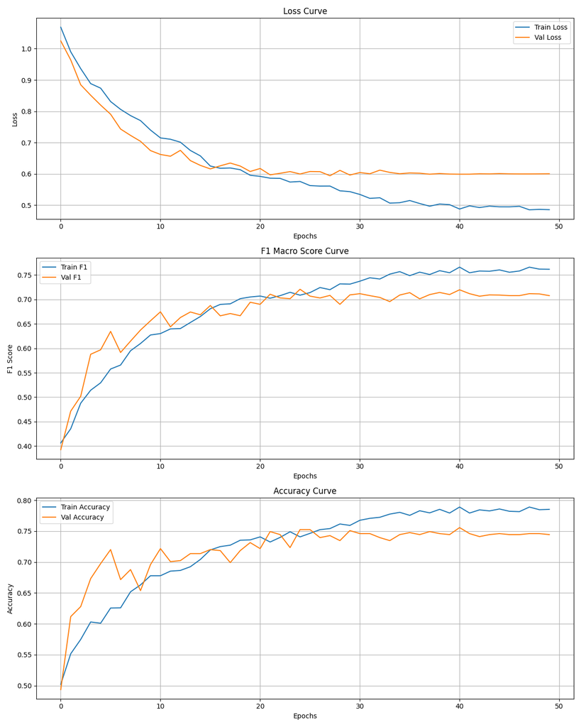

LSTM Learning Curves

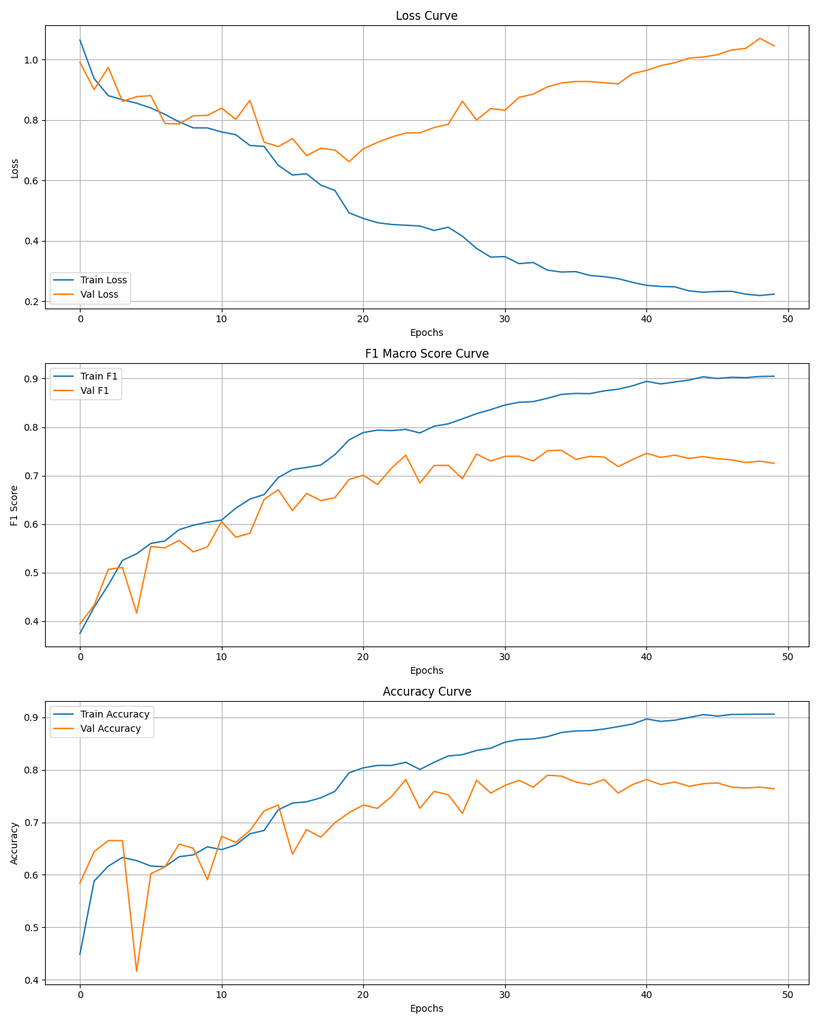

```python
from IPython.display import Image, display, Markdown

display(Markdown("### MLP Learning Curves"))
display(Image(filename="outputs/mlp_f1_learning_curves.png", width=700))

display(Markdown("### LSTM Learning Curves"))
display(Image(filename="outputs/lstm_f1_learning_curves.png", width=700))
```

### How did using class weights affect training stability and final performance?

The dataset is imbalanced: Neutral ~59%, Positive ~28%, Negative ~14%. Without class weights the models would just predict Neutral most of the time and get decent accuracy but bad recall on the minority classes.

## 2. Model Performance and Error Analysis

*Focus on MLP and LSTM implementations*

MLP Confusion Matrix

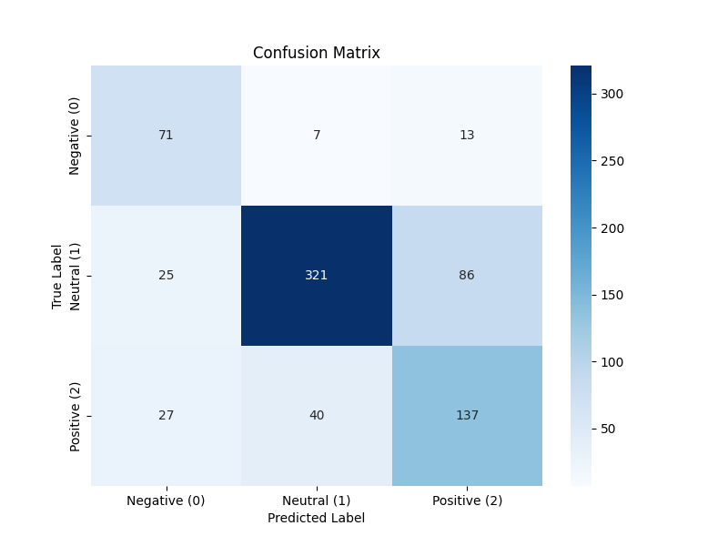

LSTM Confusion Matrix

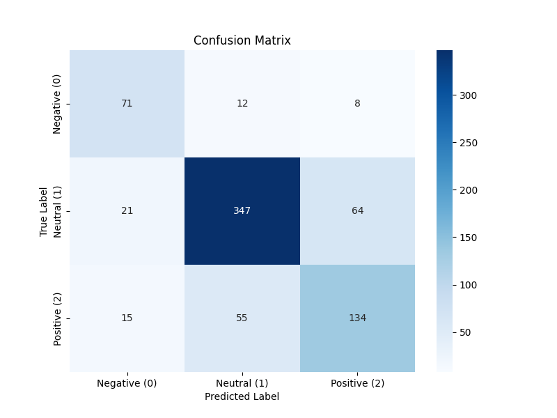

```python
from IPython.display import Image, display, Markdown

display(Markdown("### MLP Confusion Matrix"))
display(Image(filename="outputs/mlp_confusion_matrix.png", width=500))

display(Markdown("### LSTM Confusion Matrix"))
display(Image(filename="outputs/lstm_confusion_matrix.png", width=500))
```

### Which of your two models generalized better to the test set? Provide evidence from your metrics.

The LSTM generalized better:

[output not shown]

The LSTM beats the MLP by about 3.4 points in macro F1, consistently across all three classes. It processes the full sequence of 32 token embeddings rather than a single mean-pooled vector, so it can pick up on word order and patterns like negation ("not good") that the MLP misses entirely.

### Which sentiment class was most frequently misclassified? Propose reasons for this pattern.

From the confusion matrices, **Positive** is the most misclassified class for both models, with the lowest per-class F1.

Reasons:

1. **Positive vs. Neutral is ambiguous in financial text.** A sentence like "Revenue increased by 3%" states a positive fact but reads like neutral reporting. The boundary is pretty subjective.
2. **Fewer Positive training examples** (~28% vs. ~59% Neutral). Even with class weights, the model doesn't see enough Positive patterns to reliably distinguish them.
3. **Shared vocabulary.** Positive and Neutral sentences both use the same financial terms, company names, and numbers. The sentiment signal is often just one or two subtle words.

## 3. Cross-Model Comparison

*Compare all six models: MLP, RNN, LSTM, GRU, BERT, GPT*

MLP - Learning Curves & Confusion Matrix

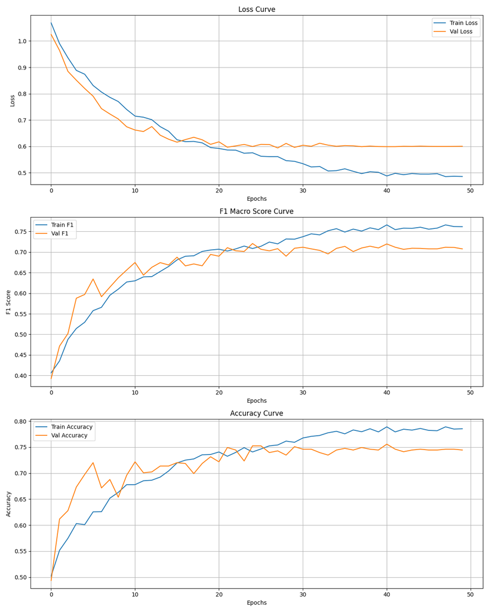

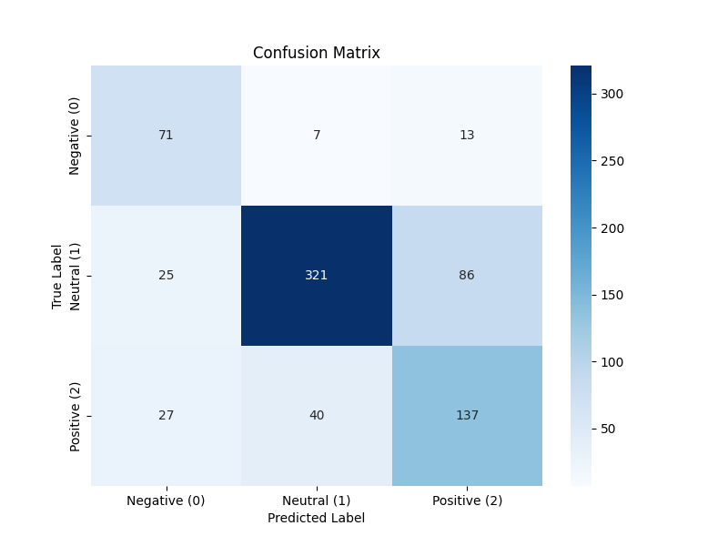

RNN - Learning Curves & Confusion Matrix

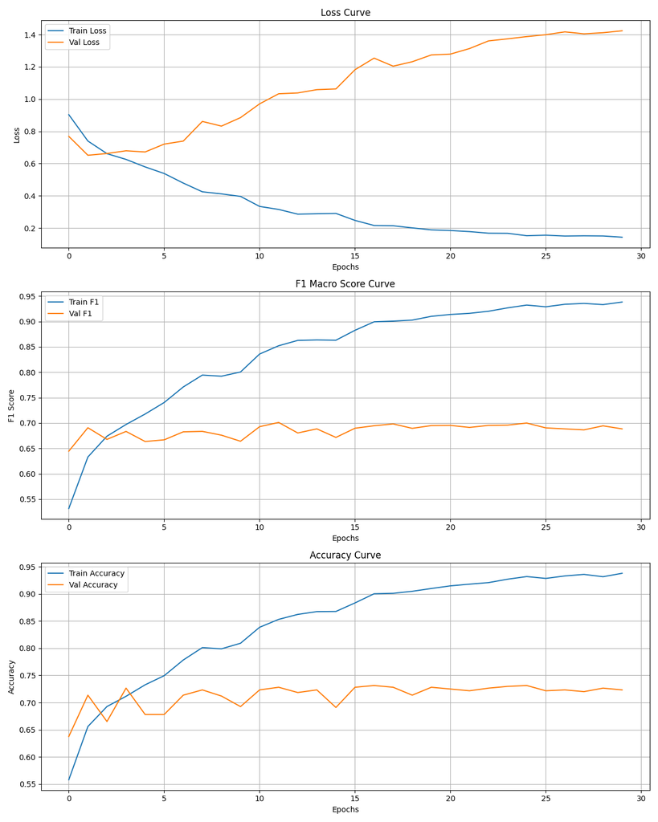

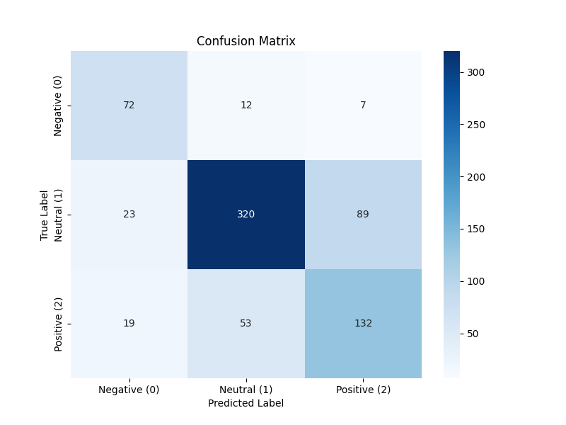

LSTM - Learning Curves & Confusion Matrix

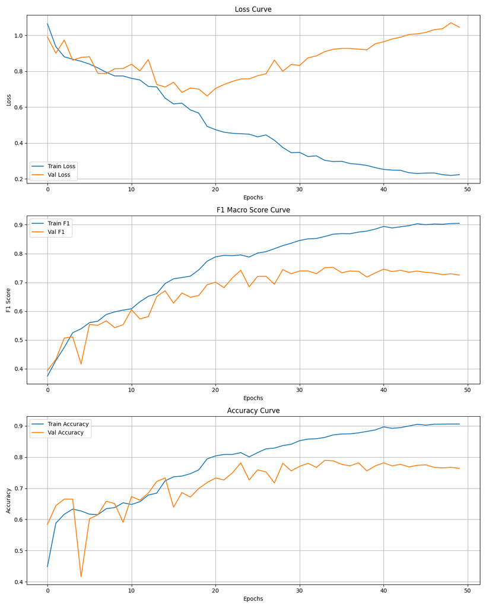

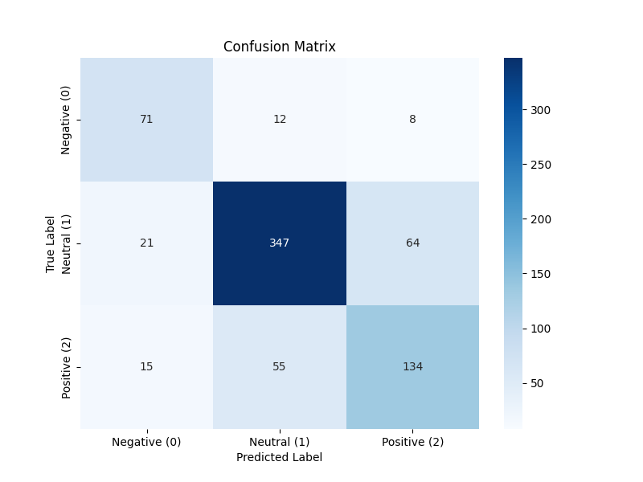

GRU - Learning Curves & Confusion Matrix

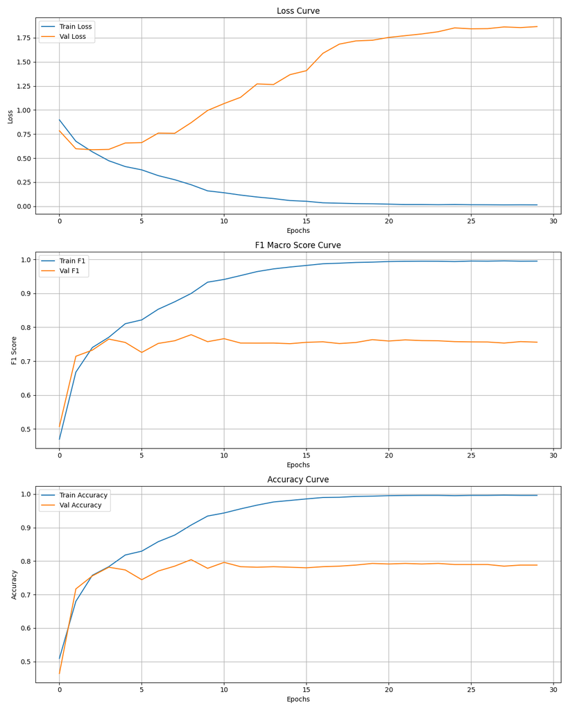

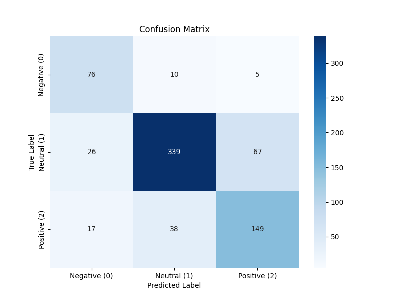

BERT - Learning Curves & Confusion Matrix

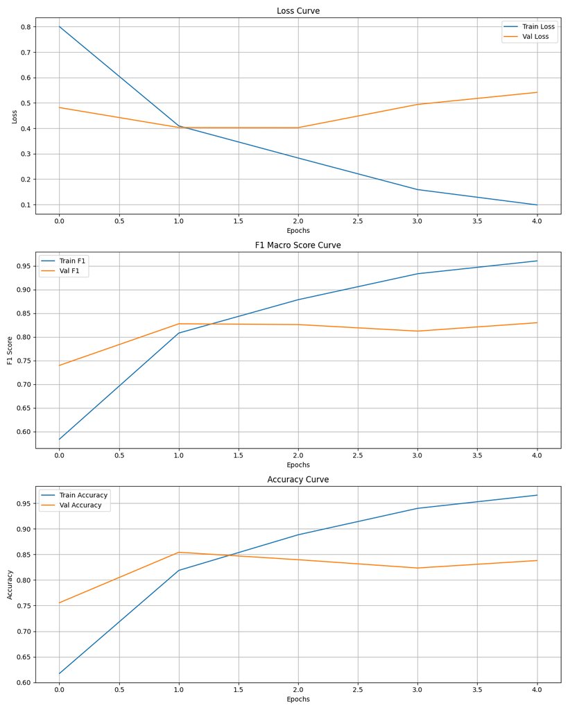

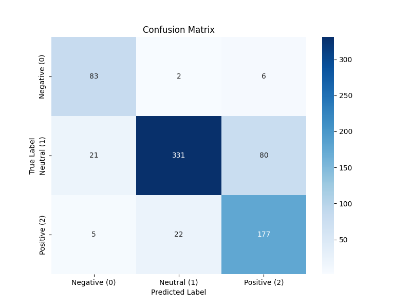

GPT - Learning Curves & Confusion Matrix

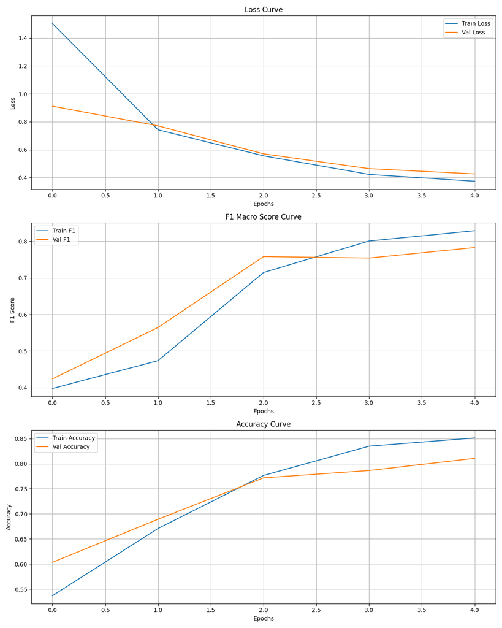

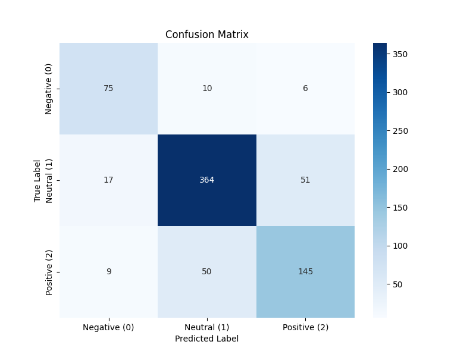

```python
from IPython.display import Image, display, Markdown

models = ['mlp', 'rnn', 'lstm', 'gru', 'bert', 'gpt']
titles = ['MLP', 'RNN', 'LSTM', 'GRU', 'BERT', 'GPT']

for model_name, title in zip(models, titles):
    display(Markdown(f"### {title} - Learning Curves & Confusion Matrix"))
    display(Image(filename=f"outputs/{model_name}_f1_learning_curves.png", width=650))
    display(Image(filename=f"outputs/{model_name}_confusion_matrix.png", width=450))
    display(Markdown("---"))
```

### How did mean-pooled FastText embeddings limit the MLP compared to sequence-based models?

Mean-pooling averages all word embeddings into one 300-dim vector. This throws away:

1. **Word order:** "profit fell sharply" and "sharply fell profit" get the same representation.
2. **Negation/modifiers:** "did not report a profit" and "did report a profit" look almost identical since they share most words.
3. **Sentiment signal gets diluted:** Sentiment words like "increased" or "declined" get averaged in with all the neutral filler (company names, dates, numbers).

Sequence models (RNN, LSTM, GRU) process all 32 token embeddings in order, so they can learn position-dependent patterns and weight important tokens through their hidden states.

### What advantage did the LSTM's sequential processing provide over the MLP?

Three main things:

1. **Sequential context:** The LSTM reads tokens one by one and builds up information, so it can handle things like "despite lower revenue" setting up a contrast.
2. **Gating:** The forget/input/output gates let it selectively keep or drop information at each step, which helps when the key sentiment word shows up early or late.
3. **Bidirectional processing:** Our LSTM reads forward and backward, giving full context around every token.

Result: LSTM F1 0.7304 vs. MLP F1 0.6963 (+3.4 points).

### Did fine-tuned LLMs (BERT/GPT) outperform classical baselines? Explain the performance gap in terms of pretraining and contextual representations.

Yes, both beat the classical models by a wide margin:

| Model | Test F1 Macro | Gap vs. MLP |
| --- | --- | --- |
| BERT | **0.8097** | +11.3 pts |
| GPT-2 | **0.7820** | +8.6 pts |
| GRU | 0.7509 | +5.5 pts |
| LSTM | 0.7304 | +3.4 pts |
| RNN | 0.6990 | +0.3 pts |
| MLP | 0.6963 | baseline |

Two reasons for the gap:

1. **Pretraining:** BERT and GPT-2 were pretrained on billions of tokens (Wikipedia, BookCorpus, WebText), so they already know a lot about language before seeing any of our financial data. The classical models start from static FastText embeddings that only capture word-level meaning.
2. **Contextual embeddings:** BERT and GPT-2 give each word a different representation depending on context. "Rose" in "stock rose 5%" gets a different embedding than in "she rose from her seat." FastText gives the same vector no matter what.

BERT edges out GPT-2 (0.8097 vs. 0.7820) probably because BERT's bidirectional encoder sees the whole sentence at once, while GPT-2 only looks left-to-right. For classification where you have the full input, bidirectional helps.

### Rank all six models by test performance. What architectural or representational factors explain the ranking?

[output not shown]

What explains this:

1. **BERT and GPT-2 on top** because of pretraining + contextual representations. BERT's bidirectional attention gives it the edge over GPT-2 for classification.
2. **GRU and LSTM in the middle.** GRU slightly beats LSTM — possibly because its simpler gating (2 gates vs. 3) generalizes better on this small dataset. Also the RNN/GRU scripts use SentenceTransformer embeddings (from a pretrained transformer), which are stronger than the static FastText embeddings the LSTM uses.
3. **RNN roughly ties with MLP** despite being a sequence model. The vanishing gradient problem prevents it from learning long-range dependencies effectively. It also overfits badly (train F1 > 0.93 vs. val F1 ~0.70).
4. **MLP last** because mean-pooling throws away word order and context. Still gets F1 0.6963 though, showing that the average embedding carries some useful sentiment signal on its own.